# Practical Machine Learning Final

Aleksandra Cvetanovska

10/28/2021

## Exploratory Analysis

We remove all columns that have at least one NA value because most model predictions don’t work with NA values. We see that after removing the columns with NA values, have only 60 columns (from 160). We also remove all un-needed columns such as user_name & time stamps. There’s 5 classes - A, B, C, D, & E. According to the authors, “class A corresponds to the specified execution of the exercise, while the other 4 classes correspond to common mistakes” (http:/groupware.les.inf.puc-rio.br/har#ixzz4TjqBfZbO). We also prepare our data for cross validation, by dividing the training set into training (70%) & validation (30%). The expected out-of-sample error will be represented by the expected number of missclassified observations/total observations in the clean_testing data set.

```r
dim(clean_training)
```

```
## [1] 13737    53
```

```r
table(clean_training$classe)
```

```
##
##    A    B    C    D    E
## 3906 2658 2396 2252 2525
```

## Prediction Model 1 - Decision Tree

First, we try to predict using the `Recursive Partitioning and Regression Trees` method. We see that the accuracy of this model, which uses all variables that are left, is ~74% with a kappa of ~.67. According to the p-value, although our model has only ~74% accuracy rate, it does offer significantly better performance that the NIR (No Information Rate) model which predicts by always using the majority class label. We also plot the `rpart` model, for a visual representation.

```r
clean_validation$classe <- as.factor(clean_validation$classe)
rpart_model <- rpart(classe~., data=clean_training, method = 'class')
rpart_predict <- predict(rpart_model, clean_validation, type = 'class')
rpart_confusion_matrix <- confusionMatrix(rpart_predict, clean_validation$classe)
rpart_confusion_matrix
```

```
## Confusion Matrix and Statistics
##
##           Reference
## Prediction    A    B    C    D    E
##          A 1521  165   28   52   15
##          B   79  715  102   92  216
##          C   51  151  835  155  120
##          D   15   93   61  607   80
##          E    8   15    0   58  651
##
## Overall Statistics
##
##                Accuracy : 0.7356
##                  95% CI : (0.7241, 0.7468)
##     No Information Rate : 0.2845
##     P-Value [Acc > NIR] : < 2.2e-16
##
##                   Kappa : 0.6648
##
##  Mcnemar's Test P-Value : < 2.2e-16
##
## Statistics by Class:
##
##                      Class: A Class: B Class: C Class: D Class: E
## Sensitivity            0.9086   0.6277   0.8138   0.6297   0.6017
## Specificity            0.9383   0.8970   0.9018   0.9494   0.9831
## Pos Pred Value         0.8540   0.5939   0.6364   0.7091   0.8893
## Neg Pred Value         0.9627   0.9094   0.9582   0.9290   0.9164
## Prevalence             0.2845   0.1935   0.1743   0.1638   0.1839
## Detection Rate         0.2585   0.1215   0.1419   0.1031   0.1106
## Detection Prevalence   0.3026   0.2046   0.2229   0.1455   0.1244
## Balanced Accuracy      0.9234   0.7624   0.8578   0.7895   0.7924
```

```r
rpart_confusion_matrix$overall[1]
```

```
## Accuracy
## 0.735599
```

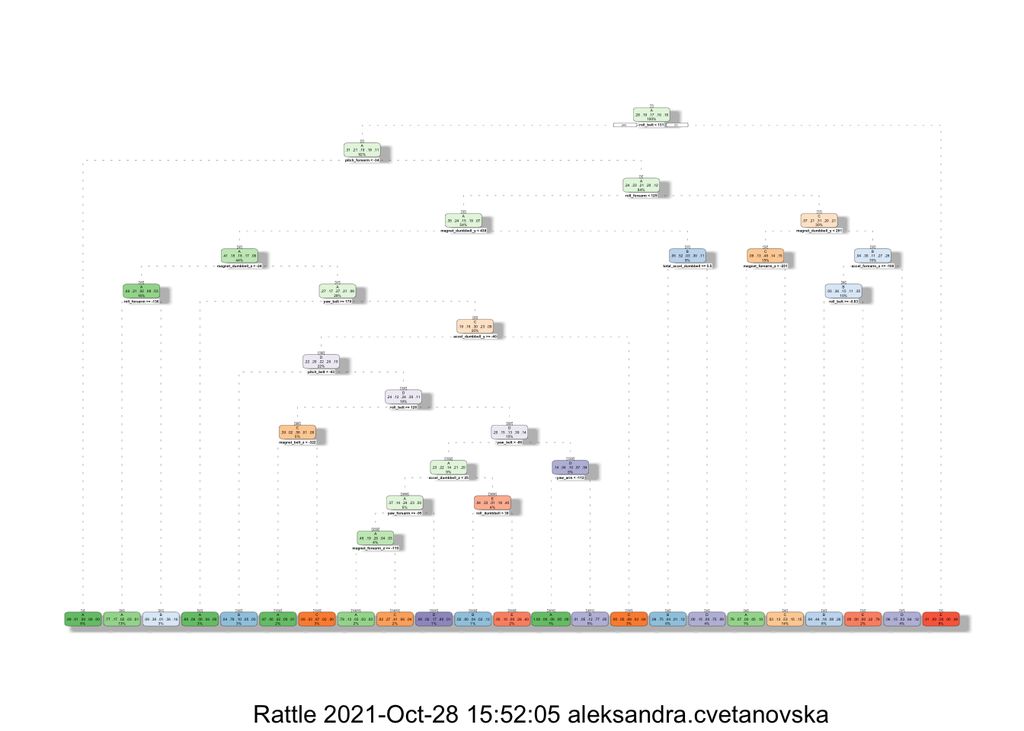

```r
fancyRpartPlot(rpart_model)
```

## Prediction Model 2 - Random Forest

```r
clean_training$classe <- as.factor(clean_training$classe)
rf_model <- randomForest(classe~., data=clean_training, method = 'class')
rf_predict <- predict(rf_model, clean_validation, type = 'class')
rf_confusion_matrix <- confusionMatrix(rf_predict, clean_validation$classe)
rf_confusion_matrix
```

```
## Confusion Matrix and Statistics
##
##           Reference
## Prediction    A    B    C    D    E
##          A 1674    6    0    0    0
##          B    0 1133    6    0    0
##          C    0    0 1020    9    1
##          D    0    0    0  955    1
##          E    0    0    0    0 1080
##
## Overall Statistics
##
##                Accuracy : 0.9961
##                  95% CI : (0.9941, 0.9975)
##     No Information Rate : 0.2845
##     P-Value [Acc > NIR] : < 2.2e-16
##
##                   Kappa : 0.9951
##
##  Mcnemar's Test P-Value : NA
##
## Statistics by Class:
##
##                      Class: A Class: B Class: C Class: D Class: E
## Sensitivity            1.0000   0.9947   0.9942   0.9907   0.9982
## Specificity            0.9986   0.9987   0.9979   0.9998   1.0000
## Pos Pred Value         0.9964   0.9947   0.9903   0.9990   1.0000
## Neg Pred Value         1.0000   0.9987   0.9988   0.9982   0.9996
## Prevalence             0.2845   0.1935   0.1743   0.1638   0.1839
## Detection Rate         0.2845   0.1925   0.1733   0.1623   0.1835
## Detection Prevalence   0.2855   0.1935   0.1750   0.1624   0.1835
## Balanced Accuracy      0.9993   0.9967   0.9960   0.9952   0.9991
```

```r
rf_confusion_matrix$overall[1]
```

```
##  Accuracy
## 0.9960918
```

## Conclusion

```r
predict(rf_model, clean_testing, type="class")
```

```
##  1  2  3  4  5  6  7  8  9 10 11 12 13 14 15 16 17 18 19 20
##  B  A  B  A  A  E  D  B  A  A  B  C  B  A  E  E  A  B  B  B
## Levels: A B C D E
```